# Statistical tests as linear models - unrankling ranks

# The premise

Jonas Lindeløv wrote a [nice blog post](https://lindeloev.github.io/tests-as-linear/#3_pearson_and_spearman_correlation) explaining how common statistical tests amount to special cases of linear regression. This is real neat unfication of tests that at first pass look unrelated. His work included examples of nonparametric tests, based on ranks. But he seems to dismiss nonparametric tests as not that different from parametric ones. That seemed off. But I realized that my intuition for what ranks do to datawas too limited to say for sure. So I made some examples here to try and understand ranks better.

# Verification

## Parametric

First, I just want to try a couple examples of parametric tests from Jonas’ post to make sure things check out.

### Correlation (Pearsons)

We’ll need 20 samples for the equivilance to be exact.

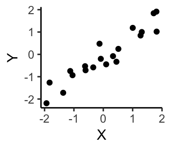

```r
# Create some data that covaries
covar <- matrix(c(1, 0.8, 1, 0.8), ncol=2)
M <- mvrnorm(n = 20, rep(0, 2), Sigma=covar)
X <- M[,1]
Y <- M[,2]
M %>%
  as.data.frame() %>%
  ggplot(aes(x=V1, y=V2)) +
  geom_point() +
  theme_classic() +
  labs(x="X", y="Y")
```

```r
rm(M, covar)
```

```r
# Built in Pearons
a <- cor.test(X,Y)
at <- tidy(a)
# Equivalent linear model
b <- lm(Y ~ 1 + X)
bt = tidy(b)[2, ]  # Only slope
bt$conf.low = confint(b)[2,1]
bt$conf.high = confint(b)[2,2]
bt$method <- "lm(y ~ 1 + x)"
print(full_join(at, bt))
```

| estimate | statistic | p.value | parameter | conf.low | conf.high | method | alternative | term | std.error |
| --- | --- | --- | --- | --- | --- | --- | --- | --- | --- |
| 0.9009975 | 8.811422 | 6.029634e-08 | 18 | 0.7624887 | 0.9605409 | Pearson's product-moment correlation | two.sided | NA | NA |
| 0.7703061 | 8.811422 | 6.029634e-08 | NA | 0.5866407 | 0.9539714 | lm(y ~ 1 + x) | NA | X | 0.08742132 |

### *t*-test (one variable)

We’ll need 20 samples for the equivilance to be exact.

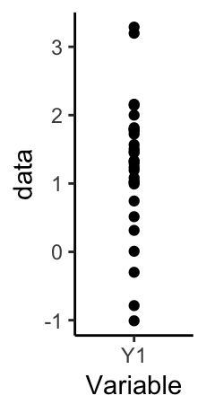

```r
# Built-in t-test
a = t.test(Y1)
at <- tidy(a)
at$df = a$parameter

# Equivalent linear model
b = lm(Y1 ~ 1)
bt <- tidy(b)
bt$conf.low = confint(b)[1]
bt$conf.high = confint(b)[2]
bt$df = b$df.residual
bt$method <- "lm(y ~ 1)"

print(full_join(at, bt))
```

[output not shown]

### *t*-test (two variable)

```r
Y0 <- rnorm(30, mean=0, sd=1)
Y1 <- rnorm(30, mean=1, sd=1)
df0 <- data.frame(data=Y0, name=rep("Y0", length(Y0)), N=1:length(Y0))
df1 <- data.frame(data=Y1, name=rep("Y1", length(Y1)), N=1:length(Y1))
df <- full_join(df0, df1)
```

```
Column `name` joining factors with different levels, coercing to character vector
```

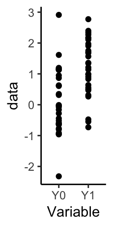

```r
df %>%
  ggplot(aes(x=name, y=data, group=N)) +
  geom_point() +
  # geom_line(size=0.5) +
  theme_classic() +
  labs(x="Variable", y="data")
```

```r
rm(df0, df1)
```

| estimate1 | estimate2 | statistic | p.value | parameter | conf.low | conf.high | method | alternative | df | term | estimate | std.error |
| --- | --- | --- | --- | --- | --- | --- | --- | --- | --- | --- | --- | --- |
| 0.1101915 | 1.108254 | -4.373392 | 5.150836e-05 | 58 | 0.6010024 | 1.6155065 | Two Sample t-test | two.sided | 58 | NA | NA | NA |
| 1.2184460 | -1.108254 | -4.373392 | 5.150836e-05 | NA | -1.6155065 | -0.6010024 | Y ~ 1 + I(group=='Y0') | NA | 58 | I(group == "Y0")TRUE | -1.108254 | 0.2534084 |

## Nonparametric

Now let’s try their nonparametric equivilants.

They, umm, don’t seem as exact as the post suggests. I don’t *think* I’ve done something wrong.

```r
# Create some data that covaries
covar <- matrix(c(1, 0.8, 1, 0.8), ncol=2)
M <- mvrnorm(n = 20, rep(0, 2), Sigma=covar)
X <- M[,1]
Y <- M[,2]
# Built in Pearons
a <- cor.test(X, Y, method="spearman")
at <- tidy(a)
# Equivalent linear model
b <- lm(rank(Y) ~ 1 + rank(X))
bt = tidy(b)[2, ]  # Only slope
# bt$conf.low = confint(b)[2,1]
# bt$conf.high = confint(b)[2,2]
bt$method <- "lm(rank(y) ~ 1 + rank(x))"
print(full_join(at, bt))
```

| estimate | statistic | p.value | method | alternative | term | std.error |
| --- | --- | --- | --- | --- | --- | --- |
| 0.9082707 | 122.000000 | 2.424756e-06 | Spearman's rank correlation rho | two.sided | NA | NA |
| 0.9082707 | 9.210378 | 3.118101e-08 | lm(rank(y) ~ 1 + rank(x)) | NA | rank(X) | 0.09861383 |

```r
rm(covar, M)
```

### *t*-test (one variable)

| statistic | p.value | method | alternative | term | estimate | std.error |
| --- | --- | --- | --- | --- | --- | --- |
| 1185.000000 | 1.289420e-07 | Wilcoxon signed rank test with continuity correction | two.sided | NA | NA | NA |
| 7.875635 | 2.961369e-10 | lm(signed_rank(Y1) ~ 1) | NA | (Intercept) | 21.9 | 2.780728 |

### *t*-test (two variable)

```r
Y0 <- rnorm(30, mean=0, sd=1)
Y1 <- rnorm(30, mean=1, sd=1)
# Built-in t-test
a = wilcox.test(Y1, Y0)
at <- tidy(a)
# Equivalent linear model
Y = c(Y0, Y1)
group = rep(c('Y0', 'Y1'), each = 30)
b = lm(rank(Y) ~ 1 + I(group=='Y0'))
bt <- tidy(b)
bt$method <- "rank(Y) ~ 1 + I(group=='Y0')"
# tmp = at$conf.high
# at$conf.high = -at$conf.low
# at$conf.low = -tmp
# at$estimate2 = at$estimate2 - at$estimate1  # Make it the difference
# at$df = at$parameter
#
# # lm
# bt$conf.low = confint(b)[2,1]
# bt$conf.high = confint(b)[2,2]
# bt$estimate1 = bt$estimate[1]
# bt$estimate2 = bt$estimate[2]
# bt$df = b$df.residual
print(full_join(at, bt[2,]))
```

| statistic | p.value | method | alternative | term | estimate | std.error |
| --- | --- | --- | --- | --- | --- | --- |
| 638.000000 | 0.004994396 | Wilcoxon rank sum test | two.sided | NA | NA | NA |
| -2.956143 | 0.004498278 | rank(Y) ~ 1 + I(group=='Y0') | NA | I(group == "Y0")TRUE | -12.53333 | 4.239759 |

# Ranks

What does ranking do to data?

To find out let’s first try some different noise distributions, then some outliers, and finally some linear and nonlinear series.

## Gaussian noise

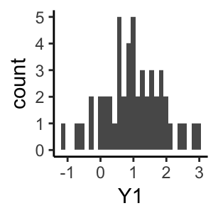

```
Column `name` joining factors with different levels, coercing to character vectorColumn `name` joining character vector and factor, coercing into character vector
```

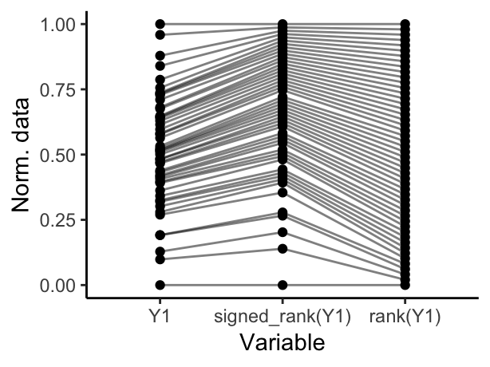

## Exponential noise

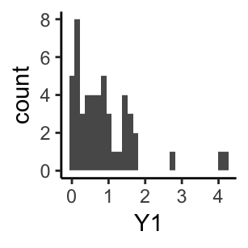

```
Column `name` joining factors with different levels, coercing to character vectorColumn `name` joining character vector and factor, coercing into character vector
```

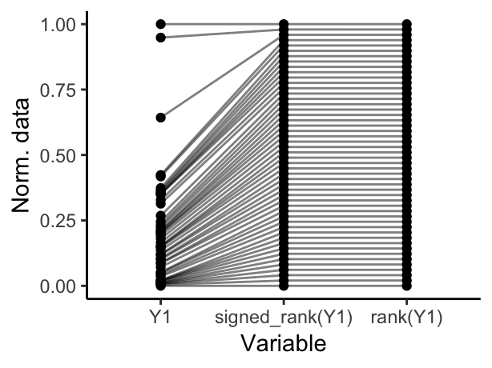

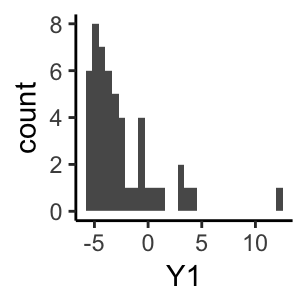

```
Column `name` joining factors with different levels, coercing to character vectorColumn `name` joining character vector and factor, coercing into character vector
```

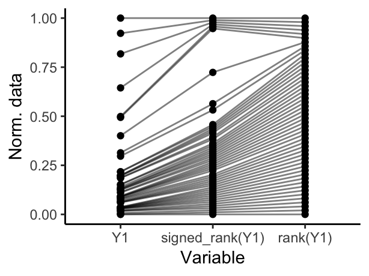

## Linear data

### Identical noise

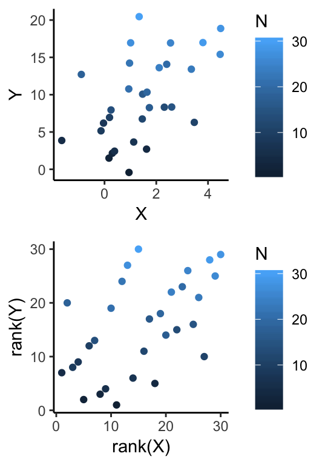

### Different variance

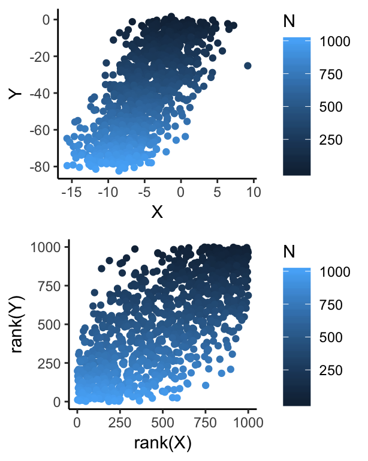

### Change in variance

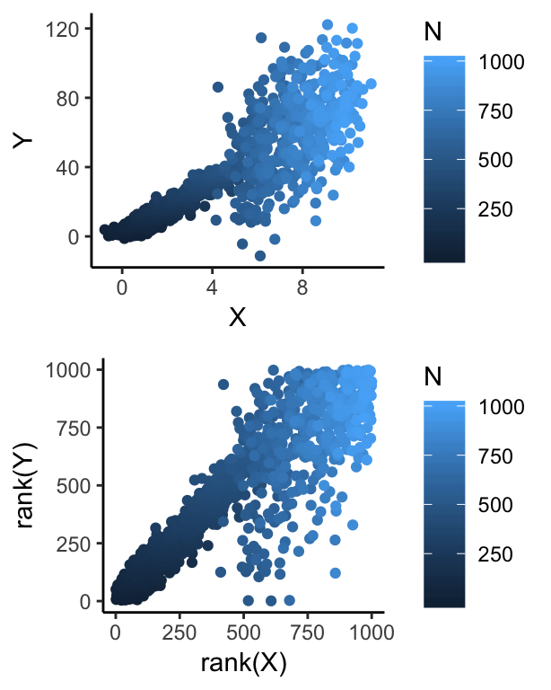

### Different distributions

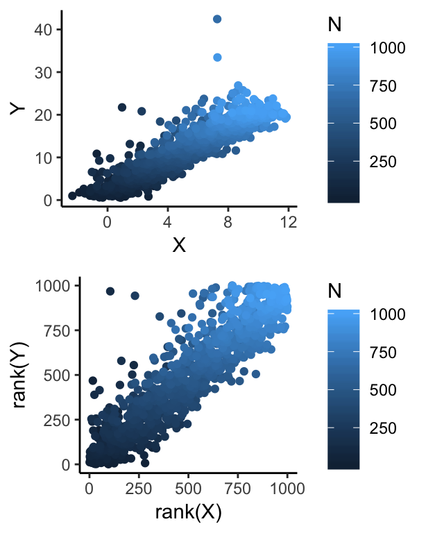